# Data and Measurement

# Exercises - Week 3

In this tutorial, we will carry out exercises on criterion and content validity. We will also deal with some data wrangling tasks. Below you will find detailed information on the data sets we will use.

Overview of datasets

- depression_data.csv: A group of social science researchers working in the field of mental health develop a new assessment tool to measure depressive symptoms. To check the concurrent validity of their new tool they run a survey to 300 respondents where they administer their new tool at the same time with the more established measure, the Beck Depression Inventory (BDI).
- official_records.csv: This data set contain information on the voter turnout for a sample of citizens from offical records.
- self_reported_voting.csv: This data set contains the results of a survey in which some citizens were asked about their voting behavior in the last elections.
- organizational_data.csv: This dataset contains information on six items to measure organizational knowledge and organizational performance. All items are measured at the organizational level.

Organizational Performance Items: Financial Performance: This item measures revenue growth. Customer Satisfaction: This item measures customer satisfaction scores. Employee Productivity: This item measures sales per employee.

Organizational Knowledge Items: Knowledge Sharing: This item measures the extent to which employees share knowledge and information within the organization through channels such as meetings, email, or collaborative platforms. Learning and Development: This item measures the organization’s investment in employee training and development programs, including the number of training hours per employee or the percentage of employees participating in training. Innovation Culture: This item measures the organization’s culture of innovation, including factors such as the encouragement of new ideas, the willingness to take risks, and the support for experimentation.

### Exercise 1 - Criterion-related validity

1. Load the “depression_data.csv” into R environment.

```r
# Read the CSV file into R
depression_data <- read.csv("/Users/msimsek/Desktop/UvA/Teaching/Data_and_Measurement_RMSS/2024/W3/Tutorials/depression_data.csv")
```

2. Print the first few rows of the dataset to have a quick look at the data

```r
#Print the first few rows of the dataframe
head(depression_data)
```

| Participant_ID | New_Assessment_Scores | BDI_Scores |
| --- | --- | --- |
| 1 | 12 | 15 |
| 2 | 14 | 15 |
| 3 | 23 | 15 |
| 4 | 15 | 13 |
| 5 | 16 | 19 |
| 6 | 24 | 28 |

3. Visualize the BID results with the new_assessment results (Hint: you can check the relationship between them as well as their distributions).

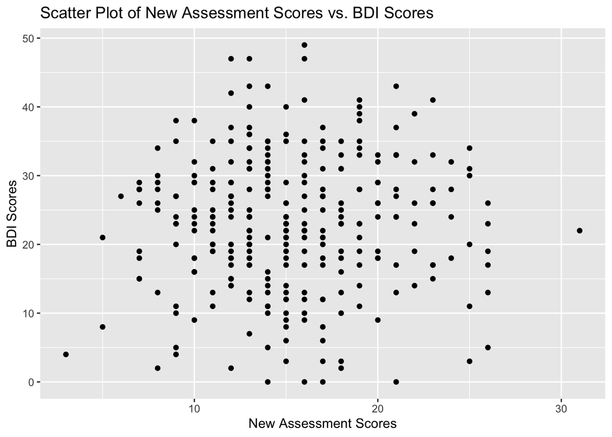

```r
library(ggplot2)
# Create a scatter plot
scatter_plot <- ggplot(data = depression_data, aes(x = New_Assessment_Scores, y = BDI_Scores)) +
  geom_point() +  # Add points
  labs(x = "New Assessment Scores", y = "BDI Scores") +  # Add axis labels
  ggtitle("Scatter Plot of New Assessment Scores vs. BDI Scores")  # Add title

#Show the plot
scatter_plot
```

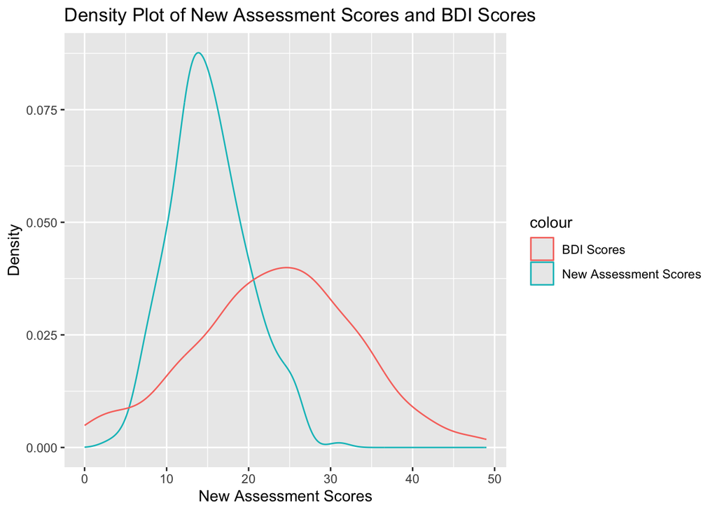

```r
# Load the ggplot2 package
library(ggplot2)

# Create a density plot for New Assessment Scores
density_plot <- ggplot(data = depression_data, aes(x = New_Assessment_Scores)) +
  geom_density(aes(color = "New Assessment Scores")) +  # Add density plot for New Assessment Scores
  labs(x = "New Assessment Scores", y = "Density") +  # Add axis labels
  ggtitle("Density Plot of New Assessment Scores and BDI Scores")  # Add title

# Add a density plot for BDI Scores on top of the existing plot
density_plot <- density_plot +
  geom_density(data = depression_data, aes(x = BDI_Scores, color = "BDI Scores"))  # Add density plot for BDI Scores

# Show the plot
print(density_plot)
```

4. What can you say about the concurrent validity of the new assessment scores? (Hint: Do the results of the new assessment tool correlate with the results of the established BDI?)

```r
# Compute the correlation between BDI scores and new assessment scores
correlation <- cor(depression_data$BDI_Scores, depression_data$New_Assessment_Scores)

# Print the correlation
cat("Correlation between BDI and New Assessment Scores:", correlation,"\n")
```

```
## Correlation between BDI and New Assessment Scores: 0.03650943
```